# Análisis scRNA-seq: Efecto de Idasanutlin y Nilotinib en LMC

# 26 Expresión diferencial entre condiciones

El análisis de expresión diferencial (DEG) compara la expresión génica entre condiciones de tratamiento dentro de cada tipo celular anotado. El objetivo principal es identificar los genes que cambian como consecuencia del tratamiento con NIL+IDASA en las LSC quiescentes

Usamos `FindMarkers()` con el test de Wilcoxon y aplicamos el umbral del paper: `|log2FC| > 0.5` y `p.adj < 0.05`.

Sin embargo, al intentar realizar el análisis diferencial entre NIL+IDASA y VEH específicamente dentro del cluster de LSC quiescentes (ESC-REGlow, cluster 8), se encontró que dicho cluster no contiene células de la condición NIL+IDASA (0 células), con solo 4 células de la condición Nilotinib frente a 333 células Vehicle. Lejos de representar un error, al igual resulta ser consistente la desaparición de las LSC quiescentes bajo el tratamiento NIL+IDASA con agotamiento de esta población. El análisis de expresión diferencial se realizó por tanto en todas las células CD34+.

```r
#  DEG en todas las células CD34+
# Captura el efecto global del tratamiento en progenitores

cd34_cells <- subset(pbmc, subset = cell_type == "huCD34")
Idents(cd34_cells) <- cd34_cells$condition

cat("Células CD34+ por condición:\n")
```

```
Células CD34+ por condición:
```

```r
table(cd34_cells$condition)
```

```
NIL_IDASA Nilotinib   Vehicle
     3256      3364      4595
```

```r
deg_cd34 <- FindMarkers(
  cd34_cells,
  ident.1         = "NIL_IDASA",
  ident.2         = "Vehicle",
  min.pct         = 0.10,
  logfc.threshold = 0.25,
  test.use        = "wilcox",
  verbose         = FALSE
)

deg_cd34$gene        <- rownames(deg_cd34)
deg_cd34$significant <- deg_cd34$p_val_adj < 0.05 &
                        abs(deg_cd34$avg_log2FC) > 0.5

cat("\nDEGs en CD34+ (NIL_IDASA vs VEH):\n")
```

```
DEGs en CD34+ (NIL_IDASA vs VEH):
```

```r
cat("  UP:", sum(deg_cd34$significant & deg_cd34$avg_log2FC > 0), "\n")
```

```
  UP: 45
```

```r
cat("  DOWN:", sum(deg_cd34$significant & deg_cd34$avg_log2FC < 0), "\n")
```

```
  DOWN: 365
```

```r
if (!dir.exists("DEG")) dir.create("DEG")
write.csv(deg_cd34, "DEG/DEG_CD34_NIL_IDASA_vs_VEH.csv", row.names = FALSE)
```

## 26.1 Volcano plot de expresión diferencial

El analisis de volcano plot para la poblacion global de celulas CD34+ revela una asimetria transcripcional rofunda inducida por el tratamiento combinado (NIL+IDASA) en comparación con el control (Vehicle)

Se observa un sesgo masivo hacia la inhibición génica, con 365 genes significativamente downregulados (puntos azules) frente a solo 45 genes upregulados (puntos rojos). Esto indica que la combinación de TKI con la inhibición de MDM2 induce un fuerte “apagado” transcripcional en el compartimento de progenitores.

El hallazgo central de esta gráfica es el comportamiento de la firma de genes asociada a la supervivencia de las células madre leucémicas, resaltados mediante rombos naranjas. Transcritos como *FOS*, *DUSP1* y *ZFP36*, identificados como pilares para la persistencia de las LSC quiescentes en el nicho de la médula ósea, se localizan de manera evidente en el cuadrante de inhibición. Esto confirma a nivel transcripcional que la reactivación de p53 mediante Idasanutlin inhibe con éxito la red ESC-REG que permite la evasión terapéutica.

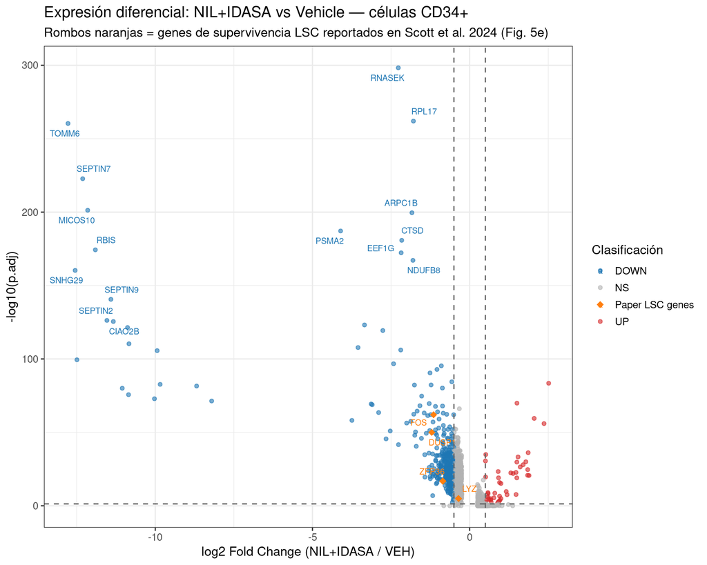

**Figura 13**. Volcano plot de expresión diferencial en células CD34+ (NIL+IDASA vs Vehicle). El eje X muestra el log2 fold change y el eje Y el -log10 del p-valor ajustado (Bonferroni-Benjamini-Hochberg). Los puntos rojos representan genes significativamente upregulados (log2FC > 0.5, p.adj < 0.05); los puntos azules, genes downregulados. Los 15 genes más significativos se etiquetan. Los genes de supervivencia de LSC reportados en el paper (FOS, DUSP1, ZFP36) se resaltan en naranja.

```r
library(ggrepel)

# Genes de supervivencia LSC reportados en el paper (Fig. 5e)
genes_paper_lsc <- c("FOS", "DUSP1", "ZFP36", "ZFP36L1", "TP53",
                     "MALAT1", "GLRX", "CNN2", "LYZ", "CD24")

deg_plot <- deg_cd34 %>%
  mutate(
    color_group = case_when(
      gene %in% genes_paper_lsc                           ~ "Paper LSC genes",
      significant & avg_log2FC > 0                        ~ "UP",
      significant & avg_log2FC < 0                        ~ "DOWN",
      TRUE                                                 ~ "NS"
    ),
    log10_padj  = -log10(p_val_adj + 1e-300)
  )

# Top 15 genes para etiquetar
top_label <- deg_plot %>%
  filter(significant) %>%
  arrange(p_val_adj) %>%
  head(15)

# Añadir genes del paper aunque no estén en top 15
genes_paper_present <- deg_plot %>%
  filter(gene %in% genes_paper_lsc, p_val_adj < 0.1)

label_genes <- bind_rows(top_label, genes_paper_present) %>%
  distinct(gene, .keep_all = TRUE)

ggplot(deg_plot, aes(x = avg_log2FC, y = log10_padj, color = color_group)) +
  geom_point(alpha = 0.6, size = 1.5) +
  geom_point(
    data   = filter(deg_plot, gene %in% genes_paper_lsc),
    size   = 3, shape = 18
  ) +
  geom_text_repel(
    data        = label_genes,
    aes(label   = gene),
    size        = 3,
    max.overlaps = 20,
    box.padding = 0.4
  ) +
  scale_color_manual(
    values = c(
      "UP"             = "#d62728",
      "DOWN"           = "#1f77b4",
      "NS"             = "grey70",
      "Paper LSC genes"= "#ff7f0e"
    ),
    name = "Clasificación"
  ) +
  geom_vline(xintercept = c(-0.5, 0.5), linetype = "dashed", color = "grey40") +
  geom_hline(yintercept = -log10(0.05),  linetype = "dashed", color = "grey40") +
  labs(
    title    = "Expresión diferencial: NIL+IDASA vs Vehicle — células CD34+",
    subtitle = "Rombos naranjas = genes de supervivencia LSC reportados en Scott et al. 2024 (Fig. 5e)",
    x        = "log2 Fold Change (NIL+IDASA / VEH)",
    y        = "-log10(p.adj)"
  ) +
  theme_bw(base_size = 13) +
  theme(legend.position = "right")
```

## 26.2 Tabla de los top DEGs significativos

El desglose cuantitativo de los top 30 genes diferencialmente expresados (ordenados por su significancia estadística) consolida y expande las observaciones del Volcano plot, revelando los mecanismos celulares específicos que están siendo reprimidos por el tratamiento con NIL+IDASA en el compartimento CD34+.

Una proporción mayoritaria de los transcritos más significativamente reprimidos (*TOMM6*, *MICOS10*, *TIMM10B*) codifican para proteínas estructurales y transportadores de la membrana mitocondrial. Adicionalmente, se observa una fuerte caída en componentes del complejo I de la cadena de transporte de electrones (*NDUFB8*, *NDUFA7*, *NDUFC2*) y enzimas del metabolismo de sulfuros (*SQOR*). Esto indica un desmantelamiento de la maquinaria de fosforilación oxidativa (OXPHOS) y de la integridad mitocondrial, un impacto esperado dado el estrés inducido por la activación de p53.

Destaca la represión drástica de múltiples miembros de la familia de las septinas (*SEPTIN2*, *SEPTIN7*, *SEPTIN9*), las cuales son fundamentales para la citocinesis y la compartimentalización celular. En conjunto con la caída de reguladores de la polimerización de actina (*ARPC1A*, *ARPC1B*), esto sugiere que las células sobrevivientes están estructuralmente comprometidas y han perdido su capacidad proliferativa.

La disminución en la expresión de subunidades del proteasoma (*PSMA2*), enzimas lisosomales (*CTSD*), factores de elongación (*EEF1G*) y proteínas ribosomales (*RPL17*), refleja un “apagado” general del recambio proteico y la traducción. Esto es altamente concordante con la inhibición del fenotipo de pluripotencia (ESC-REG), el cual se caracteriza por mantener una alta actividad transcripcional y ribosomal.

Se observa una caída masiva en la expresión de *S100A8* (log2FC de -9.94), un marcador fuertemente asociado al linaje mieloide maduro (NMM). Esto proporciona una validación robusta, a nivel de transcrito individual, de la depresión del linaje NMM que fue reportada por los autores como consecuencia del tratamiento.

```r
deg_cd34 %>%
  filter(significant) %>%
  arrange(p_val_adj) %>%
  select(gene, avg_log2FC, pct.1, pct.2, p_val_adj) %>%
  mutate(
    avg_log2FC = round(avg_log2FC, 3),
    p_val_adj  = formatC(p_val_adj, format = "e", digits = 2),
    direction  = ifelse(avg_log2FC > 0, "UP", "DOWN")
  ) %>%
  head(30)
```

|  | gene | avg_log2FC | pct.1 | pct.2 | p_val_adj | direction |
| --- | --- | --- | --- | --- | --- | --- |
| RNASEK | RNASEK | -2.270 | 0.151 | 0.581 | 5.13e-299 | DOWN |
| RPL17 | RPL17 | -1.789 | 0.190 | 0.612 | 1.02e-262 | DOWN |
| TOMM6 | TOMM6 | -12.776 | 0.000 | 0.309 | 4.27e-261 | DOWN |
| SEPTIN7 | SEPTIN7 | -12.309 | 0.000 | 0.271 | 1.77e-223 | DOWN |
| MICOS10 | MICOS10 | -12.150 | 0.000 | 0.249 | 5.58e-202 | DOWN |
| ARPC1B | ARPC1B | -1.836 | 0.321 | 0.639 | 2.65e-200 | DOWN |
| PSMA2 | PSMA2 | -4.105 | 0.012 | 0.260 | 6.92e-188 | DOWN |
| CTSD | CTSD | -2.160 | 0.226 | 0.559 | 1.61e-181 | DOWN |
| RBIS | RBIS | -11.906 | 0.000 | 0.220 | 4.88e-175 | DOWN |
| EEF1G | EEF1G | -2.179 | 0.082 | 0.366 | 5.08e-173 | DOWN |

[output cut: 20 more lines]

## 26.3 Verificación de genes clave del paper

```r
# Genes reportados en Fig. 5e del paper como downregulados en LSC quiescentes
# bajo NIL+IDASA: FOS, DUSP1, ZFP36
genes_clave <- c("FOS", "DUSP1", "ZFP36", "ZFP36L1", "TP53", "MALAT1",
                 "HBA1", "HBA2", "ALAS2", "HBB")

cat("Estado de genes clave del paper en el DEG CD34+:\n\n")
```

```
Estado de genes clave del paper en el DEG CD34+:
```

```r
deg_cd34 %>%
  filter(gene %in% genes_clave) %>%
  select(gene, avg_log2FC, p_val_adj, significant) %>%
  arrange(avg_log2FC) %>%
  print()
```

```
       gene avg_log2FC    p_val_adj significant
DUSP1 DUSP1 -1.2042494 1.102322e-50        TRUE
FOS     FOS -1.1492053 9.943598e-63        TRUE
ZFP36 ZFP36 -0.8543084 1.666384e-17        TRUE
HBB     HBB  0.9072307 4.648936e-24        TRUE
HBA1   HBA1  0.9516001 1.420390e-16        TRUE
ALAS2 ALAS2  0.9959431 6.388131e-16        TRUE
```

# 27 Enriquecimiento funcional — Gene Ontology (GO-BP)

El enriquecimiento funcional con GO-BP nos permite traducir la lista de DEGs en procesos biológicos enriquecidos, facilitando la interpretación de los cambios transcriptómicos observados bajo NIL+IDASA. Usamos `enrichGO()` de clusterProfiler con la base de datos `org.Hs.eg.db`.

Realizamos el análisis por separado para genes upregulados y downregulados en células CD34+ bajo NIL+IDASA, para identificar los procesos activados e inhibidos respectivamente.

```r
library(clusterProfiler)
library(org.Hs.eg.db)
# Genes significativos upregulados
genes_up <- deg_cd34 %>%
  filter(significant, avg_log2FC > 0) %>%
  pull(gene)

# Genes significativos downregulados
genes_down <- deg_cd34 %>%
  filter(significant, avg_log2FC < 0) %>%
  pull(gene)

cat("Genes UP significativos:", length(genes_up), "\n")
```

```
Genes UP significativos: 45
```

```r
cat("Genes DOWN significativos:", length(genes_down), "\n")
```

```
Genes DOWN significativos: 365
```

```r
# Universo: todos los genes detectados en las células CD34+
universe_genes <- rownames(cd34_cells)

# Enriquecimiento GO-BP — genes UPREGULADOS
go_up <- enrichGO(
  gene          = genes_up,
  universe      = universe_genes,
  OrgDb         = org.Hs.eg.db,
  keyType       = "SYMBOL",
  ont           = "BP",
  pAdjustMethod = "BH",
  pvalueCutoff  = 0.05,
  qvalueCutoff  = 0.2,
  readable      = TRUE
)

# Enriquecimiento GO-BP — genes DOWNREGULADOS
go_down <- enrichGO(
  gene          = genes_down,
  universe      = universe_genes,
  OrgDb         = org.Hs.eg.db,
  keyType       = "SYMBOL",
  ont           = "BP",
  pAdjustMethod = "BH",
  pvalueCutoff  = 0.05,
  qvalueCutoff  = 0.2,
  readable      = TRUE
)

cat("\nTerminos GO-BP enriquecidos (UP):", nrow(go_up@result %>% filter(p.adjust < 0.05)), "\n")
```

```
Terminos GO-BP enriquecidos (UP): 19
```

```r
cat("Terminos GO-BP enriquecidos (DOWN):", nrow(go_down@result %>% filter(p.adjust < 0.05)), "\n")
```

```
Terminos GO-BP enriquecidos (DOWN): 139
```

```r
# Guardar resultados
write.csv(go_up@result,   "DEG/GO_BP_UP_NIL_IDASA_vs_VEH.csv",   row.names = FALSE)
write.csv(go_down@result, "DEG/GO_BP_DOWN_NIL_IDASA_vs_VEH.csv", row.names = FALSE)
```